# IODS course project

Tuomas Soila

# Header 1

# Hello!

*Hopefully this course is very useful!*

*Here is my my short description of the course and my link.* *Link: (https://github.com/mannerheim/IODS-project).*

# Chapter 2 code and analysis

# section 1

*Analysis of student 2014*

- First I produced the needed subset of the original data. #Johdatus yhteiskuntatilastotieteeseen, syksy 2014 (Introduction to Social Statistics, fall 2014 - in Finnish), international survey of Approaches to Learning from http://www.helsinki.fi/~kvehkala/JYTmooc/JYTOPKYS3-data.txt Dataset contains the variables gender, age, attitude, deep, stra, surf and points by combining questions in the learning2014 data and excludes observations where the exam points variable is zero.

Deep learning questions are like this: " I usually set out to understand for myself the meaning of what we have to learn." Surface learning exercises are like this: " I find I have to concentrate on just memorising a good deal of what I have to learn." Strategic learning exercies are like this: " I think I’m quite systematic and organised when it comes to revising for exams."

```r
learning2014 <- read.csv("/Users/Tuomassoila/IODS-project/data/data1.csv")
str(learning2014)
```

```
## 'data.frame':    166 obs. of  8 variables:
##  $ X       : int  1 2 3 4 5 6 7 8 9 10 ...
##  $ gender  : Factor w/ 2 levels "F","M": 1 2 1 2 2 1 2 1 2 1 ...
##  $ Age     : int  53 55 49 53 49 38 50 37 37 42 ...
##  $ Attitude: int  37 31 25 35 37 38 35 29 38 21 ...
##  $ deep    : num  3.58 2.92 3.5 3.5 3.67 ...
##  $ stra    : num  3.38 2.75 3.62 3.12 3.62 ...
##  $ surf    : num  2.58 3.17 2.25 2.25 2.83 ...
##  $ Points  : int  25 12 24 10 22 21 21 31 24 26 ...
```

# part two

Then I continued to the actual analysis exercise

learning2014 <- read.csv(“/Users/Tuomassoila/IODS-project/data/data1.csv”)

Then I printed the graphical overview of the dataset

```r
library(ggplot2);
library(GGally)
#draws fancy scatter plot matrix
str(learning2014$Age)
```

```
##  int [1:166] 53 55 49 53 49 38 50 37 37 42 ...
```

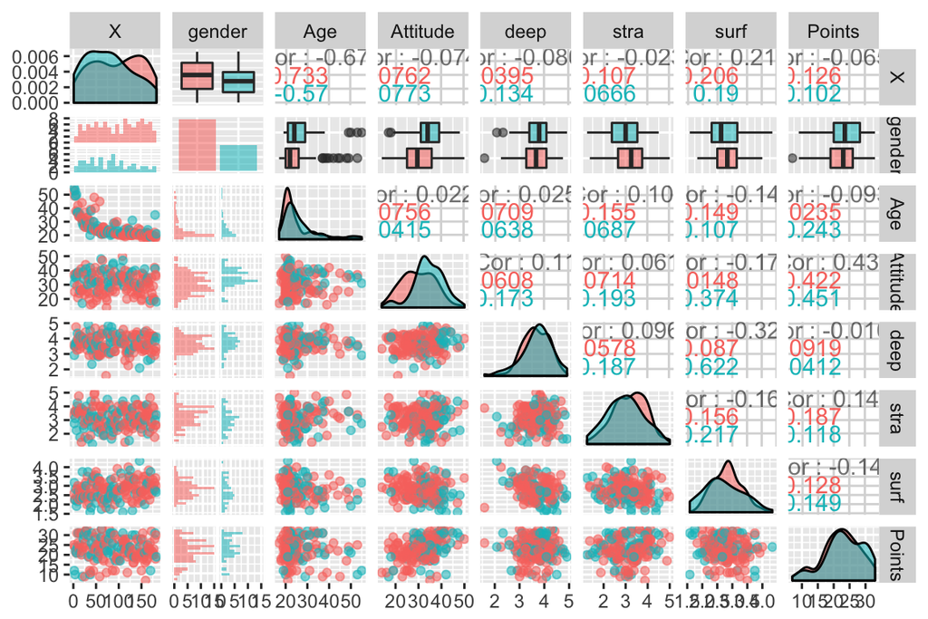

```r
p <- ggpairs(learning2014, mapping = aes(col = gender, alpha = 0.3), lower =  list(combo =wrap("facethist",bins =20)))
p
```

Age distribution is skewed towards young. Attitude is somewhat different between men and women. Women’s disctribution is more normal than men’s but neither is quite normally distributed. Deep variable is more normal yet but still not quite and a little skewed towards higher score. Stra variable quite normally distributed already. Then again surf is far from normally distributed among men and quite normal for women. Poins variable is skewed towards higher score.

# Part 3

I chose three variables for the multiple regression analysis: stra + Attitude and Age.

```r
# creates a multiple linear regression model
my_model <- lm(Points ~ stra + Attitude + Age, data = learning2014 )

summary(my_model) #prings the summary of the multiple linear regression analysis
```

```
##
## Call:
## lm(formula = Points ~ stra + Attitude + Age, data = learning2014)
##
## Residuals:
##      Min       1Q   Median       3Q      Max
## -18.1149  -3.2003   0.3303   3.4129  10.7599
##
## Coefficients:
##             Estimate Std. Error t value Pr(>|t|)
## (Intercept) 10.89543    2.64834   4.114 6.17e-05 ***
## stra         1.00371    0.53434   1.878   0.0621 .
## Attitude     0.34808    0.05622   6.191 4.72e-09 ***
## Age         -0.08822    0.05302  -1.664   0.0981 .
## ---
## Signif. codes:  0 '***' 0.001 '**' 0.01 '*' 0.05 '.' 0.1 ' ' 1
##
## Residual standard error: 5.26 on 162 degrees of freedom
## Multiple R-squared:  0.2182, Adjusted R-squared:  0.2037
## F-statistic: 15.07 on 3 and 162 DF,  p-value: 1.07e-08
```

With the results that Age is not statistically significant.

```r
my_model <- lm(Points ~ stra + Attitude, data = learning2014 ) #now only stra and attitude are set as explanatory variables
summary(my_model)
```

```
##
## Call:
## lm(formula = Points ~ stra + Attitude, data = learning2014)
##
## Residuals:
##      Min       1Q   Median       3Q      Max
## -17.6436  -3.3113   0.5575   3.7928  10.9295
##
## Coefficients:
##             Estimate Std. Error t value Pr(>|t|)
## (Intercept)  8.97290    2.39591   3.745  0.00025 ***
## stra         0.91365    0.53447   1.709  0.08927 .
## Attitude     0.34658    0.05652   6.132 6.31e-09 ***
## ---
## Signif. codes:  0 '***' 0.001 '**' 0.01 '*' 0.05 '.' 0.1 ' ' 1
##
## Residual standard error: 5.289 on 163 degrees of freedom
## Multiple R-squared:  0.2048, Adjusted R-squared:  0.1951
## F-statistic: 20.99 on 2 and 163 DF,  p-value: 7.734e-09
```

# Part 4

# part 5

Then I produced the following diagnostic plots:Residuals vs Fitted values, Normal QQ-plot and Residuals vs Leverage.

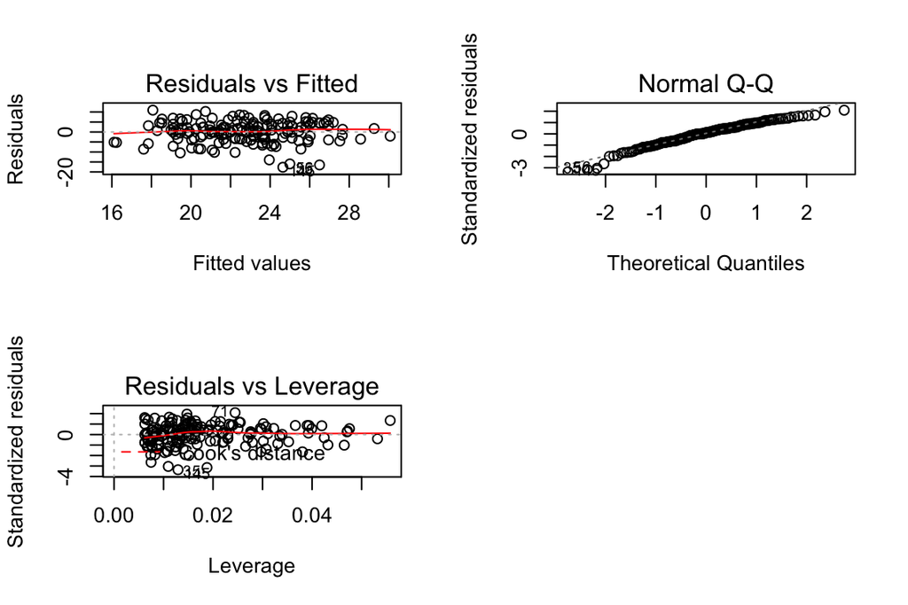

```r
par(mfrow = c(2,2)) # sets the plot in same image
plot(my_model, which=c(1,2,5)) #draws the plot number: 1,2,5 bt which command from the plot list
```

When the normal Q-Q plot is examined we can see that the normality there is some doubt about the normality since the lower and upper part does fit really well on the linear line.

On the residuals vs. fitted the distribution is reasonably random so the size of the errors do not depend on the explanatory variables.

Residuals vs leverage reveald which observations have the highest impact. In the plot we can see there are no single values that have and unausally high impact on the model.

# Chapter 3 code and analysis

## section 2

Reading the data and printing colnames and str.

```r
alc <- read.table("http://s3.amazonaws.com/assets.datacamp.com/production/course_2218/datasets/alc.txt ", sep = "," , header=TRUE)

colnames(alc)
```

```
##  [1] "school"     "sex"        "age"        "address"    "famsize"
##  [6] "Pstatus"    "Medu"       "Fedu"       "Mjob"       "Fjob"
## [11] "reason"     "nursery"    "internet"   "guardian"   "traveltime"
## [16] "studytime"  "failures"   "schoolsup"  "famsup"     "paid"
## [21] "activities" "higher"     "romantic"   "famrel"     "freetime"
## [26] "goout"      "Dalc"       "Walc"       "health"     "absences"
## [31] "G1"         "G2"         "G3"         "alc_use"    "high_use"
```

```r
str(alc)
```

```
## 'data.frame':    382 obs. of  35 variables:
##  $ school    : Factor w/ 2 levels "GP","MS": 1 1 1 1 1 1 1 1 1 1 ...
##  $ sex       : Factor w/ 2 levels "F","M": 1 1 1 1 1 2 2 1 2 2 ...
##  $ age       : int  18 17 15 15 16 16 16 17 15 15 ...
##  $ address   : Factor w/ 2 levels "R","U": 2 2 2 2 2 2 2 2 2 2 ...
##  $ famsize   : Factor w/ 2 levels "GT3","LE3": 1 1 2 1 1 2 2 1 2 1 ...
##  $ Pstatus   : Factor w/ 2 levels "A","T": 1 2 2 2 2 2 2 1 1 2 ...
##  $ Medu      : int  4 1 1 4 3 4 2 4 3 3 ...
##  $ Fedu      : int  4 1 1 2 3 3 2 4 2 4 ...
##  $ Mjob      : Factor w/ 5 levels "at_home","health",..: 1 1 1 2 3 4 3 3 4 3 ...
##  $ Fjob      : Factor w/ 5 levels "at_home","health",..: 5 3 3 4 3 3 3 5 3 3 ...
##  $ reason    : Factor w/ 4 levels "course","home",..: 1 1 3 2 2 4 2 2 2 2 ...
##  $ nursery   : Factor w/ 2 levels "no","yes": 2 1 2 2 2 2 2 2 2 2 ...
##  $ internet  : Factor w/ 2 levels "no","yes": 1 2 2 2 1 2 2 1 2 2 ...
##  $ guardian  : Factor w/ 3 levels "father","mother",..: 2 1 2 2 1 2 2 2 2 2 ...
```

[output cut: 21 more lines]

The data consist of two separate datasets that have been combined to one. Attributes for both student-mat.csv (Math course) and student-por.csv (Portuguese language course) are printed above. It has 35 variables and 382 observations. Such variables as: sex, family size, age…

## Section 3

Relationship between chosen variables and alcohol consumption

I have chosen four variables: famrel - quality of family relationships, age, studytime - weekly study time and G3 - final grade. My hypothesis is that all of these have an affect on high alcohol consumption, so that people with lower family relations quality drink more = negative effect, older students drink more = positive effect, children who study less drink more, and student with lower grades drink more.

## section 4

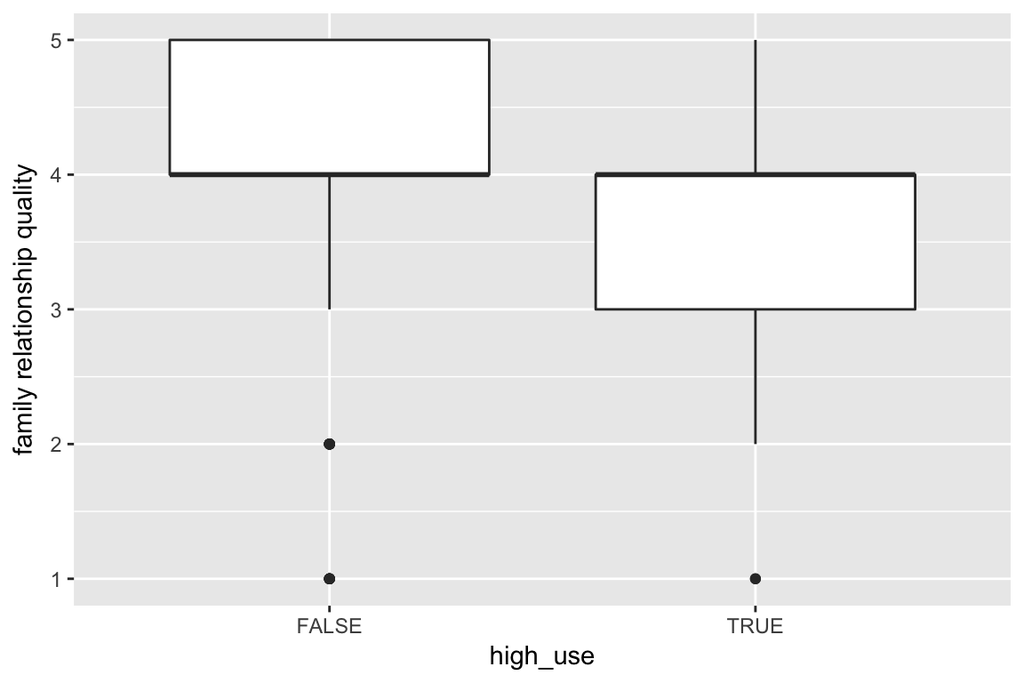

```r
library(ggplot2)
par(mfrow = c(2,2)) # adds the plots to 2 by 2 frame.

# high_use and famrel explored
g1 <- ggplot(alc, aes(x = high_use, y = famrel ))
g1 + geom_boxplot() + ylab("family relationship quality")
```

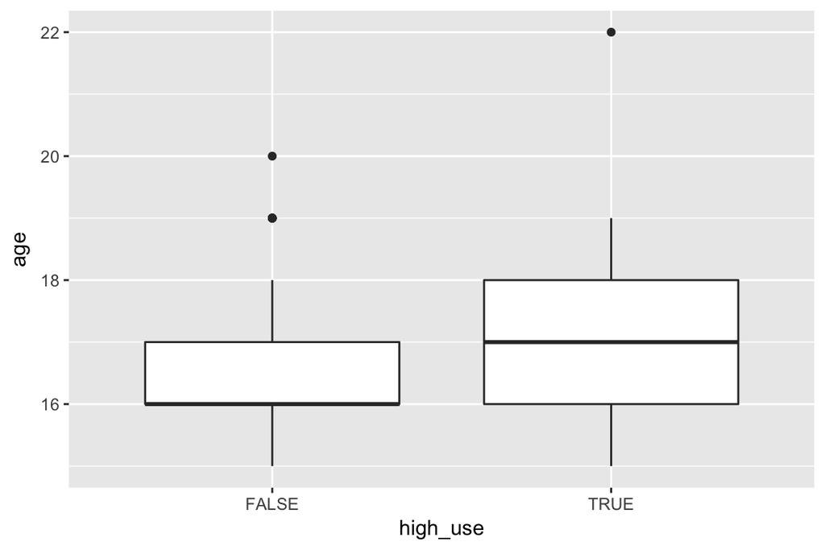

```r
#high_use and age explored
g2 <- ggplot(alc, aes(x = high_use, y = age))
g2 + geom_boxplot() + ylab("age")
```

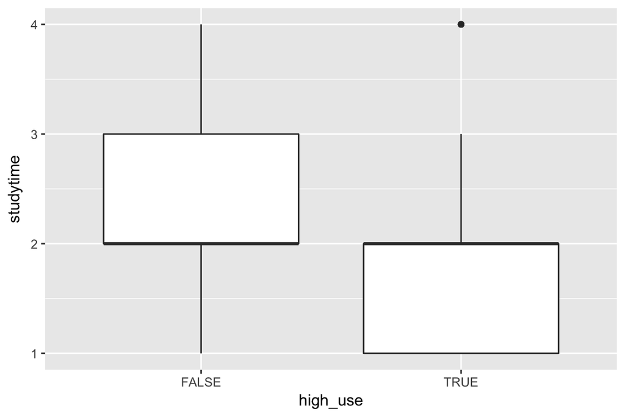

```r
#high_use and studytime explored
g3 <- ggplot(alc, aes(x= high_use, y=studytime))
g3 + geom_boxplot() + ylab("studytime")
```

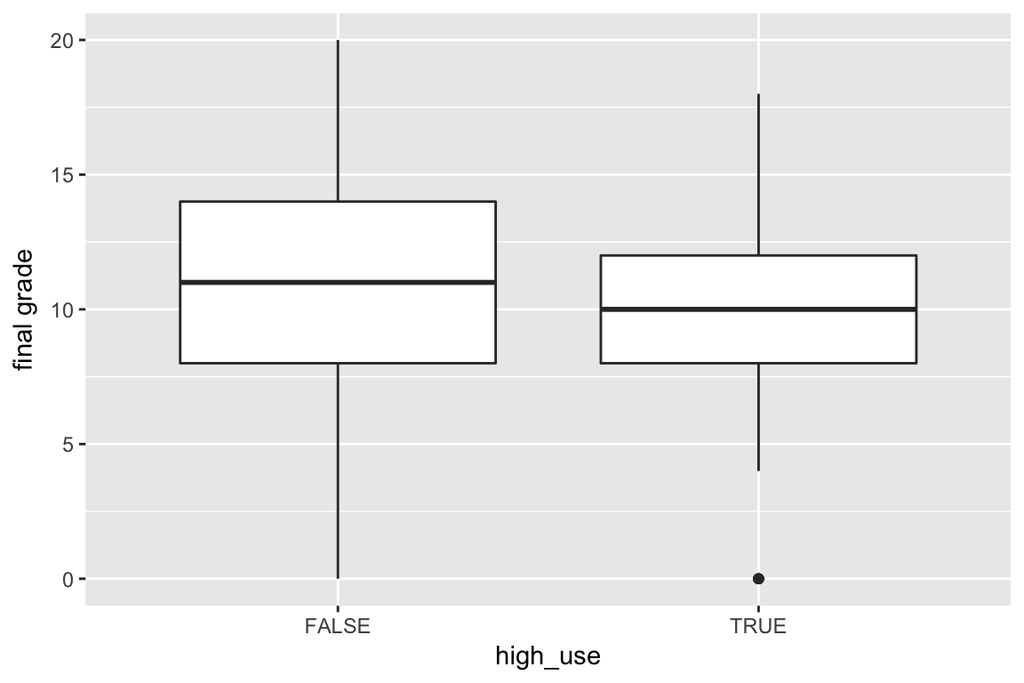

```r
#high_use and final grade explored
g4 <- ggplot(alc, aes(x=high_use, y = G3))
g4 + geom_boxplot()+ylab("final grade")
```

I then produced the bar plot for the chosen variables.

It seems that students with better family relationship quality drink less than the ones with lower quality but the averages are the same so the distributions are a bit tricky. This somewhat corresponds with my hypothesis.

As predicted older students drink more than young students.

Longer studytime means also less drinking but again the means are the same. So the distributions are tricky.

Students with higher final grade drink less than students with lower grade. But the difference is small. Corresponds with the hypothesis.

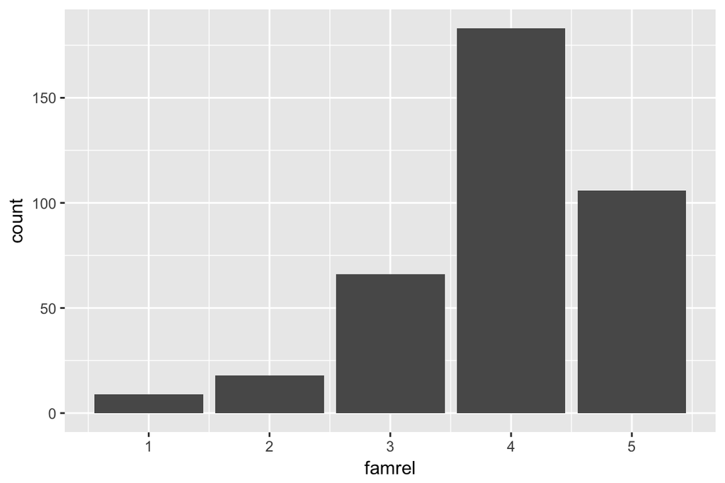

```r
library(tidyr); library(dplyr); library(ggplot2)
par(mfrow = c(2,2)) # adds the plots to 2 by 2 frame.

ggplot(data = alc, aes(famrel)) +geom_bar()
```

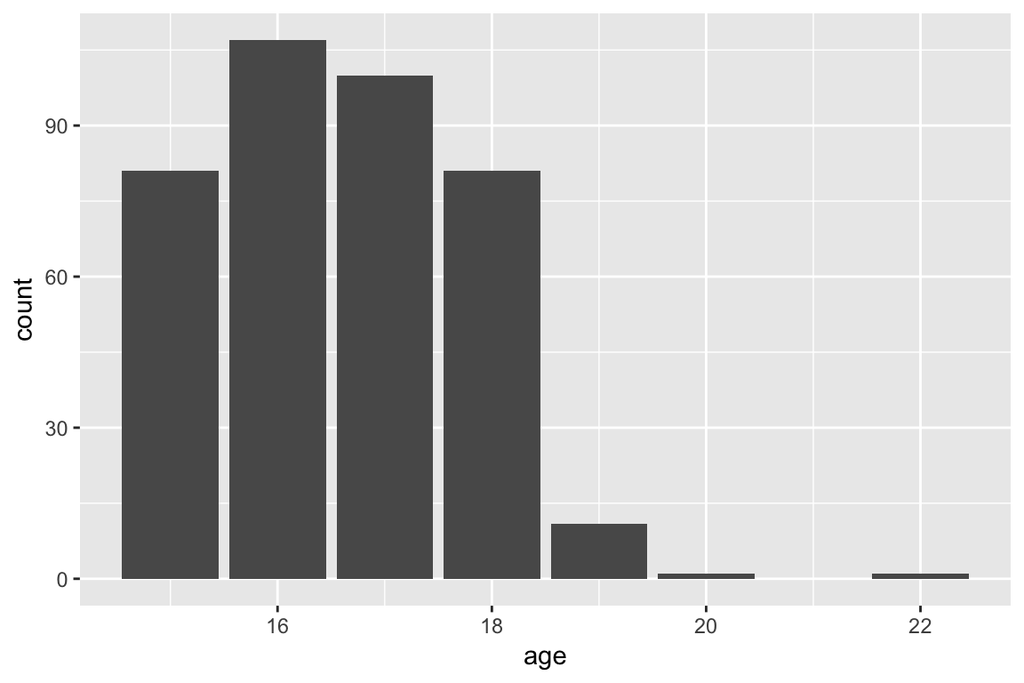

```r
ggplot(data = alc, aes(age)) +geom_bar()
```

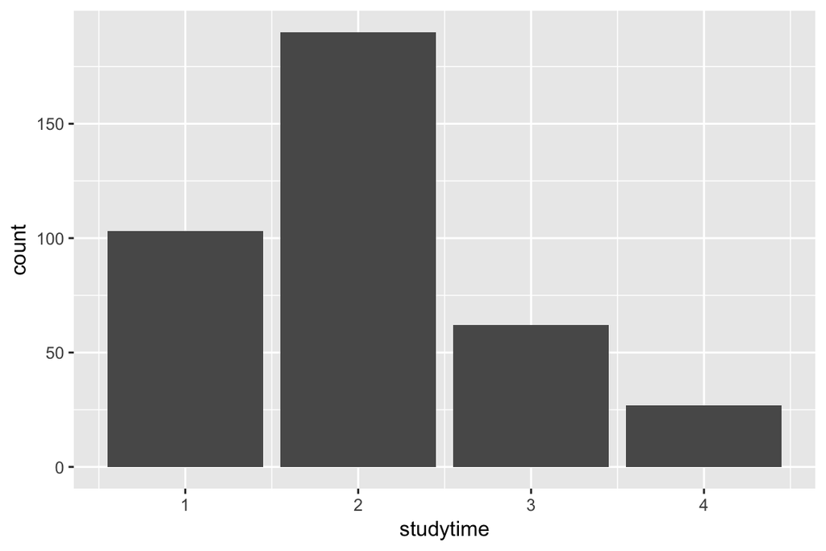

```r
ggplot(data = alc, aes(studytime)) +geom_bar()
```

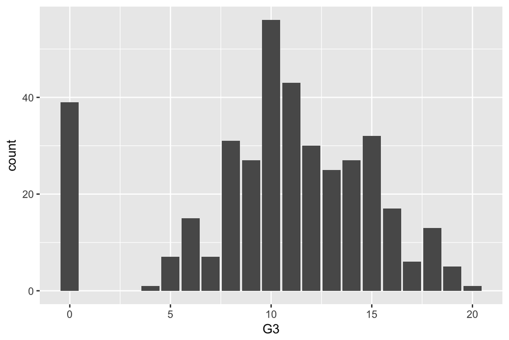

```r
ggplot(data = alc, aes(G3)) +geom_bar()
```

Then I produced the summaries of other groups. These back up the hypothesis. Group with higher studytime had we not consuming high amounts of alcohol, younger students consumed less alcohol, students consuming more alcohol had shorter studytime and students with higher grade consumed less alcohol.

```r
# access the tidyverse libraries dplyr and ggplot2
library(dplyr); library(ggplot2)
alc %>% group_by(high_use) %>% summarise(count = n(), mean_study = mean(famrel) )
```

```
## # A tibble: 2 × 3
##   high_use count mean_study
##      <lgl> <int>      <dbl>
## 1    FALSE   270   4.014815
## 2     TRUE   112   3.758929
```

```r
alc %>% group_by(high_use) %>% summarise(count = n(), age = mean(age))
```

```
## # A tibble: 2 × 3
##   high_use count      age
##      <lgl> <int>    <dbl>
## 1    FALSE   270 16.50741
## 2     TRUE   112 16.77679
```

```r
alc %>% group_by(high_use) %>% summarise(count = n(), mean_study = mean(studytime) )
```

```
## # A tibble: 2 × 3
##   high_use count mean_study
##      <lgl> <int>      <dbl>
## 1    FALSE   270   2.148148
## 2     TRUE   112   1.758929
```

```r
alc %>% group_by(high_use) %>% summarise(count = n(), mean_grade = mean(G3) )
```

```
## # A tibble: 2 × 3
##   high_use count mean_grade
##      <lgl> <int>      <dbl>
## 1    FALSE   270   10.49259
## 2     TRUE   112   10.13393
```

## Section 5

Then I produced the fitted logistic regression model with the variables chosen earlier.

```r
# find the model with glm()
m <- glm(high_use ~ age + famrel+ studytime + G3, data = alc, family = "binomial")

# print out a summary of the model
summary(m)
```

```
##
## Call:
## glm(formula = high_use ~ age + famrel + studytime + G3, family = "binomial",
##     data = alc)
##
## Deviance Residuals:
##     Min       1Q   Median       3Q      Max
## -1.5598  -0.8500  -0.6773   1.2283   2.2630
##
## Coefficients:
##             Estimate Std. Error z value Pr(>|z|)
## (Intercept) -2.21109    1.83417  -1.205   0.2280
## age          0.21512    0.10270   2.095   0.0362 *
## famrel      -0.29036    0.12427  -2.337   0.0195 *
## studytime   -0.60967    0.15517  -3.929 8.53e-05 ***
## G3           0.00651    0.02572   0.253   0.8002
## ---
## Signif. codes:  0 '***' 0.001 '**' 0.01 '*' 0.05 '.' 0.1 ' ' 1
##
## (Dispersion parameter for binomial family taken to be 1)
##
##     Null deviance: 462.21  on 381  degrees of freedom
## Residual deviance: 434.43  on 377  degrees of freedom
## AIC: 444.43
##
## Number of Fisher Scoring iterations: 4
```

```r
# print out the coefficients of the model
coef(m)
```

```
##  (Intercept)          age       famrel    studytime           G3
## -2.211091946  0.215123156 -0.290358317 -0.609675208  0.006509953
```

From the output we can see that age, famrel and studytime are statistically significant with P values less than 0.05. From this we can conclude that these variables have predictive power over high alcohol consumption. But Final grade is not statistically significant. Aging increases possibility of more alcohol consumption (0.21512), better family relations lower the odds of high alcohol consumption (-0.29036) and longer studytime has the same effect (-0.60967 ).

Odds rations: I produced the odd ratios for the model.

```r
m <- glm(high_use ~ age + famrel+ studytime + G3, data = alc, family = "binomial")
# compute odds ratios (OR)
OR <- coef(m) %>% exp

# compute confidence intervals (CI)
CI <- confint(m)%>% exp
# print out the odds ratios with their confidence intervals
cbind(OR, CI)
```

```
##                    OR       2.5 %    97.5 %
## (Intercept) 0.1095809 0.002902035 3.9454163
## age         1.2400146 1.015519368 1.5211442
## famrel      0.7479955 0.585125417 0.9540464
## studytime   0.5435274 0.396981377 0.7303409
## G3          1.0065312 0.957469303 1.0593549
```

## section 6

Now I will try if my model will predict correct answers against the actual data. I produced the confusion matrix, which according to Wikipedia works like this: “Each column of the matrix represents the instances in a predicted class while each row represents the instances in an actual class (or vice versa).”

```r
library(dplyr)

# fit the model
m <- glm(high_use ~ age + famrel+ studytime, data = alc, family = "binomial")

# predict() the probability of high_use
probabilities <- predict(m, type = "response")

# add the predicted probabilities to 'alc'
alc <- mutate(alc, probability = probabilities)

# use the probabilities to make a prediction of high_use
alc <- mutate(alc, prediction = probability>0.5)

# tabulate the target variable versus the predictions
table(high_use = alc$high_use, prediction = alc$prediction)
```

```
##         prediction
## high_use FALSE TRUE
##    FALSE   258   12
##    TRUE    101   11
```

Then I calculated the training error for my model. And if understood correctly tested it against just guessing that everyone has low alcohol consumption and the results seem that guessing works better.

```r
# (mean prediction error)
loss_func <- function(class, prob) {
  n_wrong <- abs(class - prob) > 0.5
  mean(n_wrong)
}

# loss function called with the desired attributes
loss_func(class = alc$high_use, prob = alc$probability)
```

```
## [1] 0.2958115
```

```r
loss_func(class = alc$high_use, prob = 0)
```

```
## [1] 0.2931937
```

## section 7

```r
library(boot)
cv <- cv.glm(data = alc, cost = loss_func, glmfit = m, K = 10)

# average number of wrong predictions in the cross validation
cv$delta[1]
```

```
## [1] 0.2984293
```